# Actividad

# Entregar

Archivo PDF de la actividad y la liga de la actividad en su repostitorio.

# Nota:

Las tareas 1 a la 5 se califican como entregadas o no entregadas.

Al integrante que no participe en la actividad no se le tomará en cuenta para la calificación.

El límite para entregar las actividades es el viernes antes de las 23:59.

```python
# Si trabajamos en Google Colaboratory corremos las siguientes lineas de código
from google.colab import drive
drive.mount('/content/drive/')
```

```python
# Nos cambiamos a la carpeta donde tengamos el repositorio
%cd 'drive/MyDrive/SemanaTec/arte-analitica'
```

```
/content/drive/MyDrive/SemanaTec/arte-analitica
```

# Insurance dataset

El dataset contiene información demográfica sobre los asegurado en una compañía de seguros:

- age: edad del asegurado principal
- sex: género del asegurado. female o male
- bmi: índice de masa corporal
- children: numero de niños que estan cubiertos con la poliza.
- smoke: si fuma el beneficiario. yes/no
- region: dónde vive el beneficiario. Estos datos son de Estados Unidos. Regiones disponibles: northeast, southeast, southwest, northwest
- charges: costo del seguro.

Carga el dataset `data/insurance.csv` y haz un análisis gráfico de las variables.

```python
# Carga las librerías
import seaborn as sns
import pandas as pd
import numpy as np
import matplotlib.pyplot as plt
```

```python
# Carga los datos y muestra los primeros renglones
books = pd.read_csv('data/insurance.csv')
books.head()
```

|  | age | sex | bmi | children | smoker | region | charges |
| --- | --- | --- | --- | --- | --- | --- | --- |
| 0 | 19 | female | 27.900 | 0 | yes | southwest | 16884.92400 |
| 1 | 18 | male | 33.770 | 1 | no | southeast | 1725.55230 |
| 2 | 28 | male | 33.000 | 3 | no | southeast | 4449.46200 |
| 3 | 33 | male | 22.705 | 0 | no | northwest | 21984.47061 |
| 4 | 32 | male | 28.880 | 0 | no | northwest | 3866.85520 |

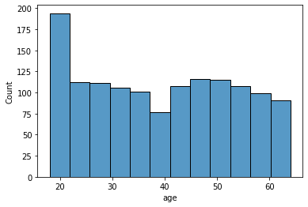

```python
# ¿Cuáles son las edades de los clientes de la aseguradora?
# Haz una gráfica de cómo se distribuye esta variable.
sns.histplot(data=books, x='age')
```

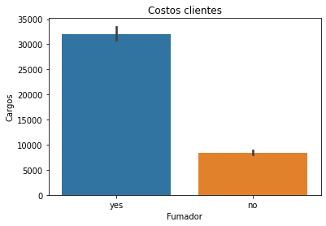

```python
# En general, quien tiene costos más altos de seguro, ¿los fumadores o los no fumadores?
# R= En promedio los fumadores pagan mas que los no fumadores

# Haz un gráfico que justifique tu respuesta.

fig = plt.figure(figsize=(6,4))

sns.barplot(data=books, x = 'smoker', y='charges', estimator=np.mean)

# Ejes y título. Colocamos la etiqueta correcta de acuerdo a la orientación.
plt.title('Costos clientes')
plt.xlabel('Fumador')
plt.ylabel('Cargos')
```

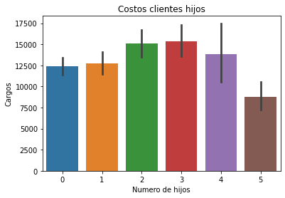

```python
# ¿Cómo varia el cargo por seguro dependiendo del número de hijos?
#R= Parece ser que la cantidad de hijos no afecta mucho los cargos del seguro, ya que los que tienen 2-3 hijos son los que mas pagan
# pero no quiere decir que entre mas hijos mas pagas porque despues de esa cantidad los cargos comienzan a bajar

# El número de hijos es una variable numérica, pero como tiene pocos valores distintos,
# la podemos considerar también como una variable cualitativa.
fig2 = plt.figure(figsize=(6,4))

sns.barplot(data=books, x = 'children', y='charges', estimator=np.mean)

# Ejes y título. Colocamos la etiqueta correcta de acuerdo a la orientación.
plt.title('Costos clientes hijos')
plt.xlabel('Numero de hijos')
plt.ylabel('Cargos')
```

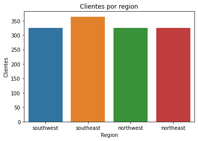

```python
# ¿Cuál es la región con más usuarios asegurados?
#R= Southeast


# Tamaño de la imagen
fig3 = plt.figure(figsize=(6,4))

# Gráfico countplot para hacer barras con el número de apariciones de cada género.
sns.countplot(data=books, x = 'region')

# Ejes y título. Colocamos la etiqueta correcta de acuerdo a la orientación.
plt.title('Clientes por region')
plt.xlabel('Region')
plt.ylabel('Clientes')
```

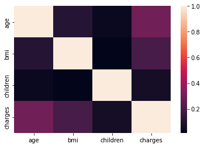

```python
# ¿Cómo se relacionan las variables numéricas entre sí?
# Muéstralo en un gráfico.
books_corr = books.corr()

# Para graficar el mapa de calor usamos heatmap. No necesitamos especificar x ni y
sns.heatmap(data=books_corr)
```

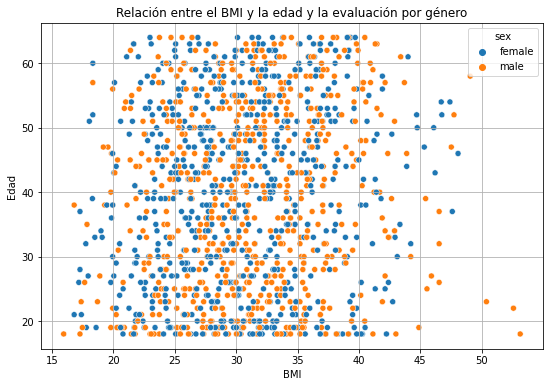

```python
# ¿Qué relación hay entre el BMI y la edad? ¿Afecta el género en esta relación?
#R= hay poca relacion entre esta variables ya que no se nota una linea de tendencia clara y el genero no parece afectar tampoco en esta correlación

# Muéstralo en un gráfico y verifica si coincide con lo que obtuviste en la pregunta anterior.

fig4 = plt.figure(figsize=(9,6))

# Gráfico scatterplot.
sns.scatterplot(data=books, x = 'bmi', y='age', hue='sex')

# Ejes y título. Colocamos la etiqueta correcta de acuerdo a la orientación.
plt.title('Relación entre el BMI y la edad y la evaluación por género')
plt.xlabel('BMI')
plt.ylabel('Edad')
plt.grid()
```

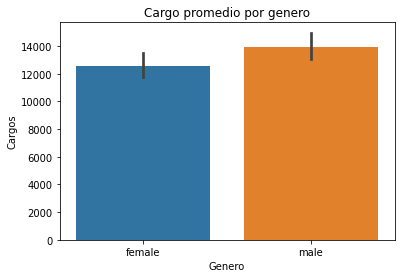

```python
# ¿Cuál es el cargo promedio por género de un seguro?
fig = plt.figure(figsize=(6,4))

sns.barplot(data=books, x = 'sex', y='charges', estimator=np.mean)

# Ejes y título. Colocamos la etiqueta correcta de acuerdo a la orientación.
plt.title('Cargo promedio por genero')
plt.xlabel('Genero')
plt.ylabel('Cargos')
```

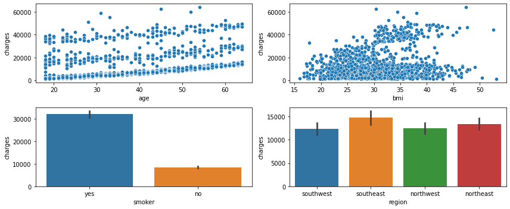

```python
# En una sola imagen, grafica las relaciones que tienen las variables
# age, bmi, smoker y region con charges.
fig, axs= plt.subplots(2,2, figsize=(12, 5))
sns.scatterplot(data=books, x = 'age', y='charges',ax=axs[0,0])
sns.scatterplot(data=books, x = 'bmi', y='charges',ax=axs[0,1])
sns.barplot(data=books, x = 'smoker', y='charges',ax=axs[1,0])
sns.barplot(data=books, x = 'region', y='charges',ax=axs[1,1])
plt.tight_layout()
```

# Guardar el resultado como pdf

- Escribe aquí abajo la liga de tu repositorio.
- (Haz doble clic en esta celda y copia la URL dentro del paréntesis)

[Liga al repositorio de Regina]Liga al repositorio de Regina

- Exporta el notebook a formato HTML.

```python
!jupyter nbconvert --to HTML '/gdrive/MyDrive/SemanaTec/arte-analitica/5.2 - Actividad - Visualizacion de datos.ipynb'
```

[output not shown]

[output cut: 107 more lines]

[output not shown]

- Haz doble clic en el archivo nuevo que se creó dentro de la carpeta `arte-analitica` y en la parte superior derecha dale clic en **imprimir**
- Imprime el archivo como *PDF* y súbelo a Canvas.